# Homework1_STAT515

Mykola Signayevskyy

2023-02-11

#### Question 1:

The data sets here consists of applications f,or admission to graduate study at the University of California, Berkeley for the Fall 1973. “Admission.csv” contains university level admission status and “Original_Admissions_Data.csv” contains admissions by each department.

1. Using GGplot create an appropriate graphic to show the university-level Admissions. (Hint: Female and male applications admitted and rejected (stacked bar plot (2 bars), admitted and rejected broken down by % male/female.) (Use Admissions.csv).

```r
library(tidyverse)
library(scales)
source("/Users/mykola/Desktop/STAT515/third_lesson/hw.R")
```

```r
admission <- read_csv("Admission.csv")
table(is.na(admission))
```

```
##
## FALSE
##    16
```

```r
summary(admission)
```

```
##     Gender             Admit                Freq           Prop
##  Length:4           Length:4           Min.   : 557   Min.   :0.3240
##  Class :character   Class :character   1st Qu.:1008   1st Qu.:0.4268
##  Mode  :character   Mode  :character   Median :1218   Median :0.5000
##                                        Mean   :1122   Mean   :0.4998
##                                        3rd Qu.:1332   3rd Qu.:0.5730
##                                        Max.   :1493   Max.   :0.6750
```

```r
str(admission)
```

```
## spc_tbl_ [4 × 4] (S3: spec_tbl_df/tbl_df/tbl/data.frame)
##  $ Gender: chr [1:4] "Male" "Female" "Male" "Female"
##  $ Admit : chr [1:4] "Admitted" "Admitted" "Rejected" "Rejected"
##  $ Freq  : num [1:4] 1158 557 1493 1278
##  $ Prop  : num [1:4] 0.675 0.324 0.539 0.461
##  - attr(*, "spec")=
##   .. cols(
##   ..   Gender = col_character(),
##   ..   Admit = col_character(),
##   ..   Freq = col_double(),
##   ..   Prop = col_double()
##   .. )
##  - attr(*, "problems")=<externalptr>
```

```r
admission$Admit_gender = paste(admission$Gender, admission$Admit, sep=' ')
print(admission)
```

```
## # A tibble: 4 × 5
##   Gender Admit     Freq  Prop Admit_gender
##   <chr>  <chr>    <dbl> <dbl> <chr>
## 1 Male   Admitted  1158 0.675 Male Admitted
## 2 Female Admitted   557 0.324 Female Admitted
## 3 Male   Rejected  1493 0.539 Male Rejected
## 4 Female Rejected  1278 0.461 Female Rejected
```

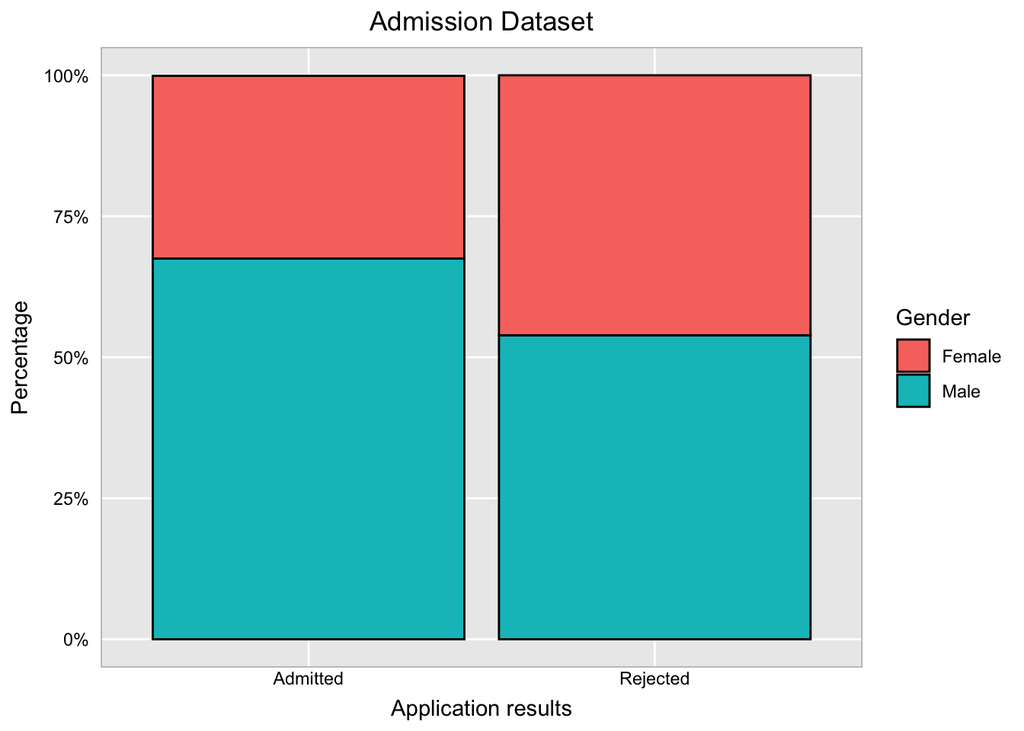

```r
ggplot(admission) +
  geom_bar(aes(x=Admit,y=Prop,fill=Gender),stat="identity", color="black") +
  scale_y_continuous(labels = scales::percent_format(accuracy = 1)) +
  labs(x="Application results",
       y="Percentage",
       title="Admission Dataset",
       fill="Gender") + hw
```

2. Assume admissions are conducted at the department level. Create an appropriate graphic to show the department level Admissions. (use Original_Admissions_Data.csv). (Hint: Let’s look at %male/female for admitted and rejected applicants by department.)

```r
admission_department <- read.csv("Original_Admissions_Data.csv")
table(is.na(admission_department))
```

```
##
## FALSE
##    30
```

```r
summary(admission_department)
```

```
##      Dept           Male_Admitted    Male_Rejected   Female_Admitted
##  Length:6           Min.   : 22.00   Min.   :138.0   Min.   : 17.00
##  Class :character   1st Qu.: 69.75   1st Qu.:205.5   1st Qu.: 40.25
##  Mode  :character   Median :129.00   Median :243.0   Median : 91.50
##                     Mean   :193.00   Mean   :248.8   Mean   : 92.83
##                     3rd Qu.:269.25   3rd Qu.:304.5   3rd Qu.:121.75
##                     Max.   :512.00   Max.   :351.0   Max.   :202.00
##  Female_Rejected
##  Min.   :  8.00
##  1st Qu.: 75.25
##  Median :271.50
##  Mean   :213.00
##  3rd Qu.:312.50
##  Max.   :391.00
```

```r
admission_department_sort <- gather(admission_department, key = application_result, value = amount,Male_Admitted:Female_Rejected,
  factor_key = T)

head(admission_department_sort, n=10)
```

```
##    Dept application_result amount
## 1     A      Male_Admitted    512
## 2     B      Male_Admitted    313
## 3     C      Male_Admitted    120
## 4     D      Male_Admitted    138
## 5     E      Male_Admitted     53
## 6     F      Male_Admitted     22
## 7     A      Male_Rejected    313
## 8     B      Male_Rejected    207
## 9     C      Male_Rejected    205
## 10    D      Male_Rejected    279
```

[figure not shown]

```r
ggplot(admission_department_sort) +
  geom_bar(aes(x=Dept,y=amount*0.001,fill=application_result),stat="identity", color="black") +
  scale_y_continuous(labels = scales::percent_format(accuracy = 1)) +
  labs(x="Application results",
       y="Percentage",
       title="Admission by Departments",
       fill="Department") + hw
```

#### Question 2:

The data set used, represents gene expression data for multiple samples. Use `gene expression.csv` for this question.

1. Create a scatter plot representing gene expression of “sampleB” on the X-axis and “sampleH” on the Y-axis. What kind of relationship do you observe?

```r
gene <- read_csv("gene expression.csv")
table(is.na(gene))
```

```
##
## FALSE  TRUE
##  9008     1
```

```r
gene = na.omit(gene)
table(is.na(gene))
```

```
##
## FALSE
##  9000
```

```r
summary(gene)
```

```
##    GeneName            sampleA          sampleB          sampleC
##  Length:1000        Min.   : 5.733   Min.   : 5.702   Min.   : 5.740
##  Class :character   1st Qu.: 6.198   1st Qu.: 6.223   1st Qu.: 6.216
##  Mode  :character   Median : 6.596   Median : 6.624   Median : 6.614
##                     Mean   : 8.155   Mean   : 8.170   Mean   : 8.173
##                     3rd Qu.:10.165   3rd Qu.:10.106   3rd Qu.:10.021
##                     Max.   :17.453   Max.   :17.512   Max.   :17.547
##     sampleD          sampleE          sampleF          sampleG
##  Min.   : 5.786   Min.   : 5.833   Min.   : 5.674   Min.   : 5.791
##  1st Qu.: 6.203   1st Qu.: 6.210   1st Qu.: 6.216   1st Qu.: 6.200
##  Median : 6.635   Median : 6.672   Median : 6.613   Median : 6.601
##  Mean   : 8.178   Mean   : 8.175   Mean   : 8.169   Mean   : 8.162
##  3rd Qu.:10.116   3rd Qu.:10.071   3rd Qu.: 9.991   3rd Qu.:10.148
##  Max.   :17.547   Max.   :17.534   Max.   :17.538   Max.   :17.646
##     sampleH
##  Min.   : 5.837
##  1st Qu.: 6.198
##  Median : 6.634
##  Mean   : 8.171
##  3rd Qu.:10.069
##  Max.   :17.557
```

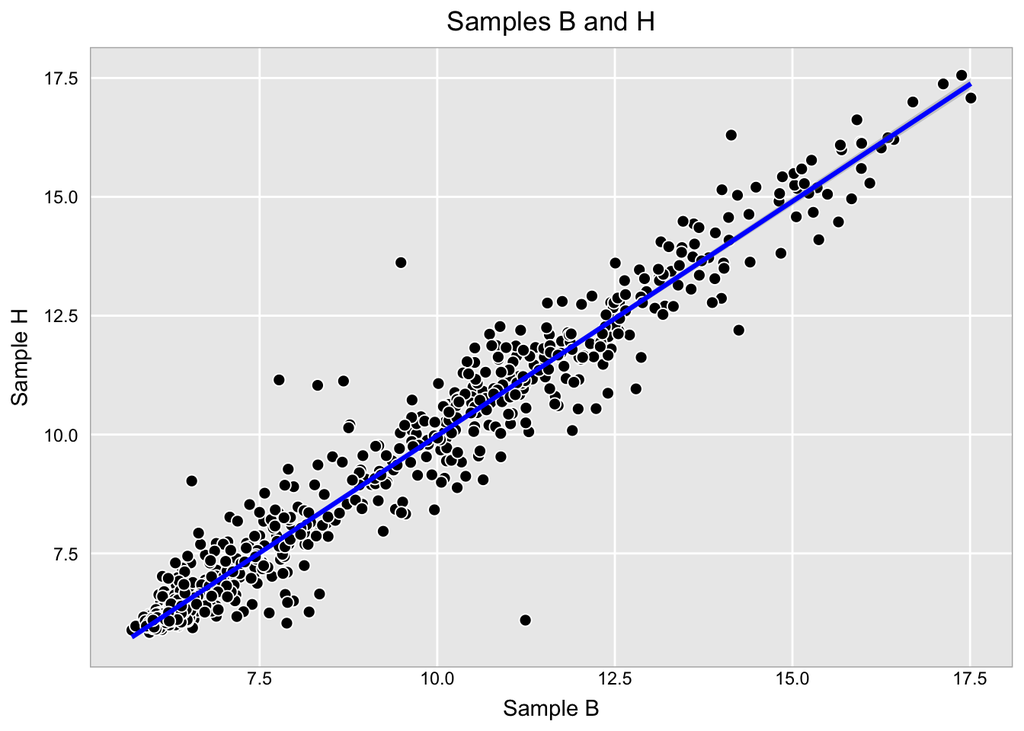

```r
plt_HB <- ggplot(gene, aes(x = sampleB, y = sampleH)) +
  geom_point(shape = 21, size = 2.5, fill = "black", color = "white") +
  geom_smooth(method = lm, color = "blue", linewidth = 1.1) +
  labs(x="Sample B",
       y="Sample H",
       title="Samples B and H") + hw
plt_HB
```

##### The graph above shows that samples B and H have pretty similar values for each gene type, with some noise exeptions.

2. Add a column to the data frame, according to the following conditions:
   - Name the new column as “expre_limit”.
   - If the expression of a gene is > 13 in both sampleB and sampleH, set to the value in “expre_limits” to “high”.
   - If the expression of a gene is < 6 in both sampleB and sampleH, set it to “low”.
   - If different, set it to “normal”.

```r
gene <- gene %>%
  mutate(expre_limit = case_when((sampleB > 13 & sampleH > 13) ~ "high",
                               (sampleB < 6 & sampleH < 6) ~ "low",
                               .default = "normal"
                               )) #adding new column "expre_limit" with described restrictions

head(gene)
```

```
## # A tibble: 6 × 10
##   GeneName      sampleA sampleB sampleC sampleD sampleE sampleF sampleG sampleH
##   <chr>           <dbl>   <dbl>   <dbl>   <dbl>   <dbl>   <dbl>   <dbl>   <dbl>
## 1 A630034I12Rik    7.63    8.23    7.99    8.17    8.13    7.89    8.00    8.06
## 2 Kat6b            6.11    6.23    6.14    6.09    6.11    6.25    6.06    6.15
## 3 Hypm             7.60    7.39    7.32    7.69    7.17    7.69    7.64    6.43
## 4 A_55_P2148744   13.9    13.6    14.2    13.5    13.4    14.2    13.9    14.4
## 5 Prima1           6.11    6.02    6.07    6.19    5.99    6.12    5.97    6.13
## 6 4930573O21Rik    6.10    6.05    6.19    6.13    6.14    6.11    6.26    6.21
## # … with 1 more variable: expre_limit <chr>
```

```r
gene %>%
  select(sampleB, sampleH, expre_limit) %>%
  head(., 10) #checking more samples to be sure everything works correctly
```

```
## # A tibble: 10 × 3
##    sampleB sampleH expre_limit
##      <dbl>   <dbl> <chr>
##  1    8.23    8.06 normal
##  2    6.23    6.15 normal
##  3    7.39    6.43 normal
##  4   13.6    14.4  high
##  5    6.02    6.13 normal
##  6    6.05    6.21 normal
##  7    7.02    6.99 normal
##  8    6.62    6.70 normal
##  9    9.41    8.43 normal
## 10    7.08    8.26 normal
```

3. Color the points of the scatter plot according to the newly created column “expre_limits”. Save that plot in the object “plot1”.
4. Rename the legend title as “Expression Limits”.

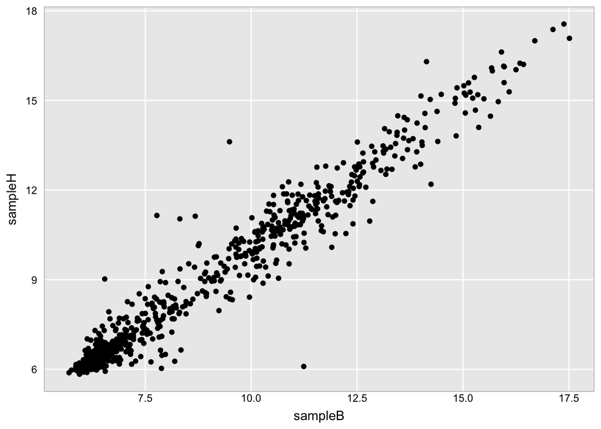

```r
gene2 <- ggplot(gene, aes( x=sampleB, y=sampleH))
gene2 + geom_point()  + hw
```

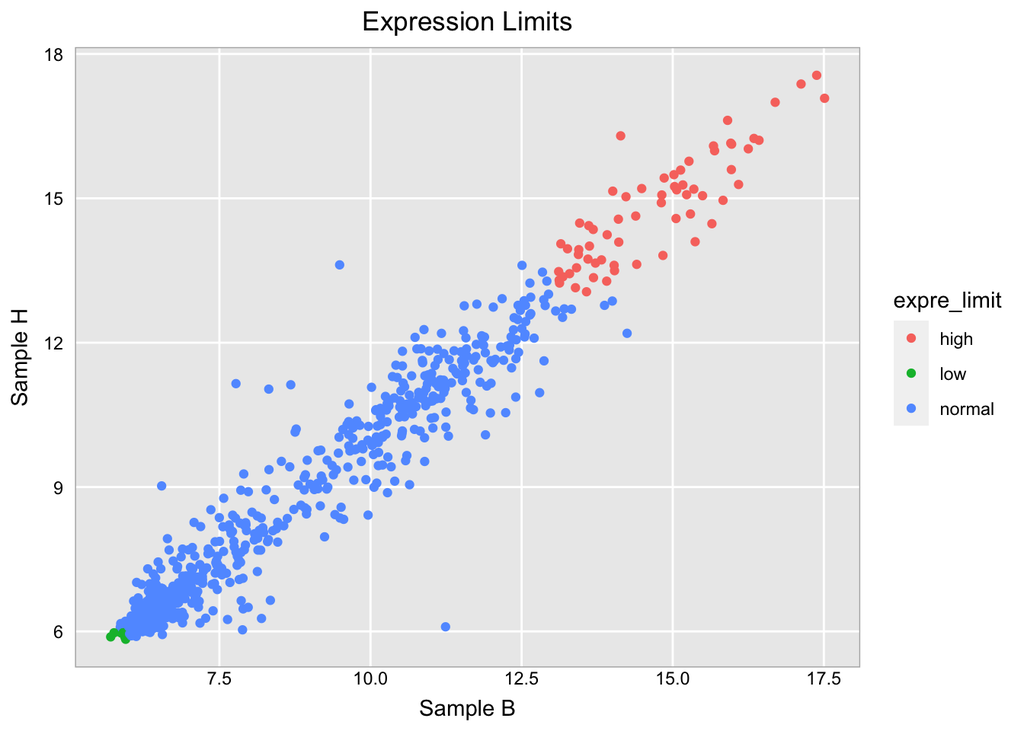

```r
plot1 <- gene2 + geom_point( aes( color = expre_limit) ) +
  labs(title = "Expression Limits",
       x="Sample B",
       y="Sample H") +hw
plot1
```

5. Add another layer to “plot1” in order to change the points colors to blue (for low), grey (for normal) and red (for high). Save this plot in the object “plot2”.

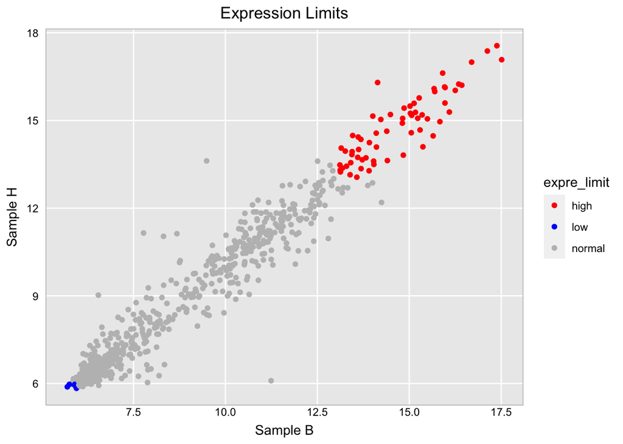

```r
plot2 <- plot1 + scale_color_manual(values=c("red","blue", "grey"))+ hw
plot2
```

6. Produce a bar plot of how many low/normal/high genes are in the column ‘expre_limits’. Save this plot as “plot3”.

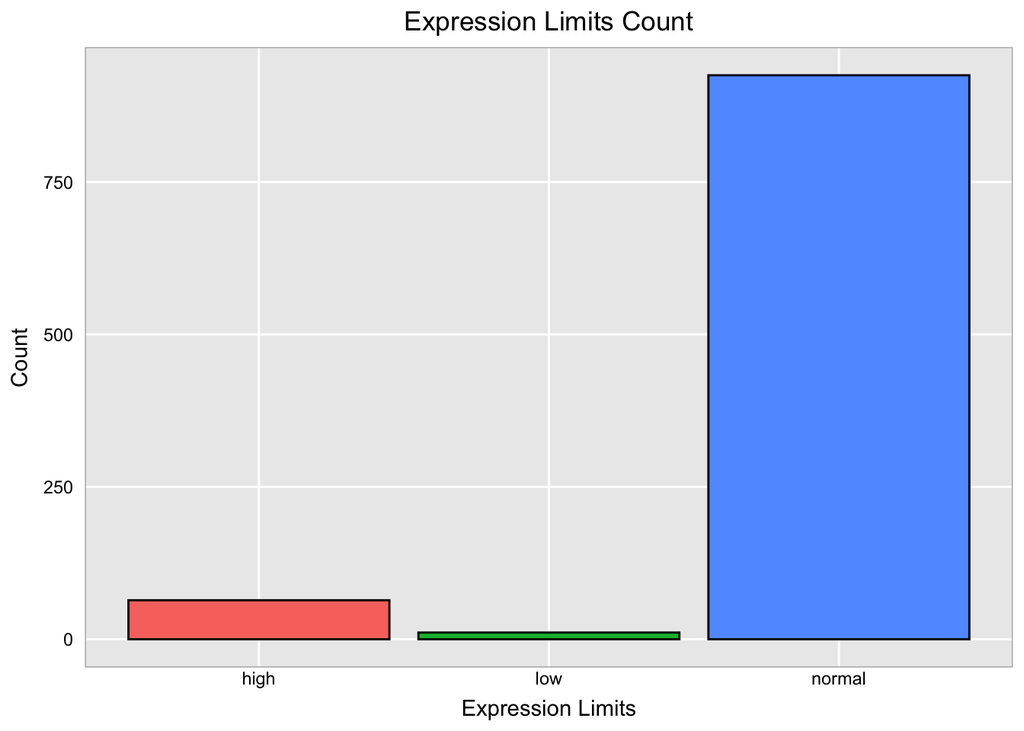

```r
plot3 <- ggplot(gene, aes(x=expre_limit, fill=expre_limit))+
  geom_bar(color="black") +
  labs(x="Expression Limits",
       y="Count",
       title="Expression Limits Count")+ hw +
  theme(legend.position="none")
plot3
```

7. To plot3, add an horizontal line at counts = 250

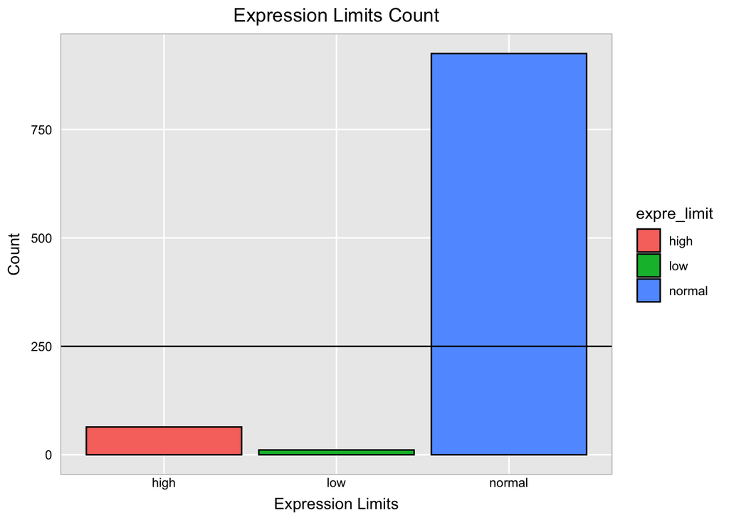

```r
plot3 <- plot3 + geom_hline(yintercept=250) + hw
plot3
```

8. Swap the X-axis and the Y-axis of the plot from part 7).

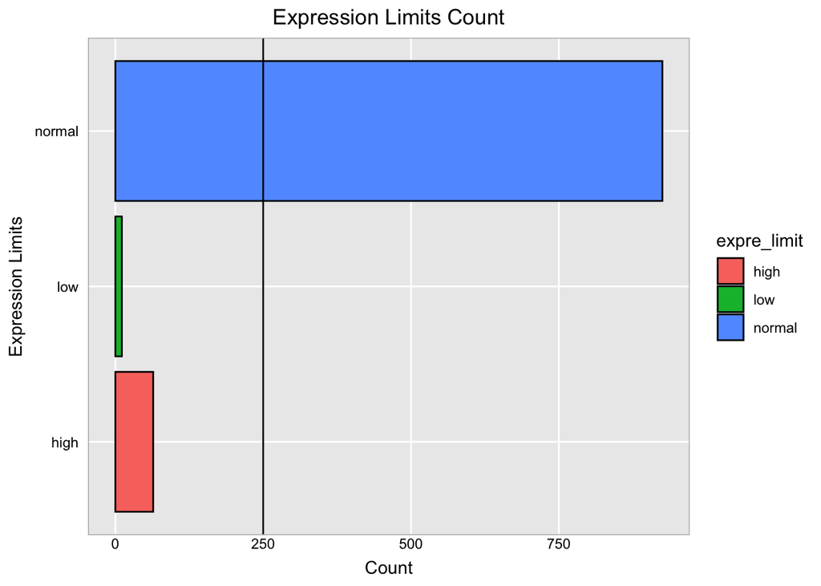

```r
plot3 + coord_flip()
```

#### Question 3:

Titanic data set from `Kaggle.com` is used for this example. Please use `titanic.csv` for this question.

1. Is there a relationship between the age of the passenger and the passenger fare? Explore this by constructing a scatter plot.

```r
titanic <- read_csv("titanic.csv")
table(is.na(titanic))
```

```
##
## FALSE
##  7096
```

```r
summary(titanic)
```

```
##     Survived          Pclass          Name               Sex
##  Min.   :0.0000   Min.   :1.000   Length:887         Length:887
##  1st Qu.:0.0000   1st Qu.:2.000   Class :character   Class :character
##  Median :0.0000   Median :3.000   Mode  :character   Mode  :character
##  Mean   :0.3856   Mean   :2.306
##  3rd Qu.:1.0000   3rd Qu.:3.000
##  Max.   :1.0000   Max.   :3.000
##       Age        Siblings/Spouses Aboard Parents/Children Aboard
##  Min.   : 0.42   Min.   :0.0000          Min.   :0.0000
##  1st Qu.:20.25   1st Qu.:0.0000          1st Qu.:0.0000
##  Median :28.00   Median :0.0000          Median :0.0000
##  Mean   :29.47   Mean   :0.5254          Mean   :0.3833
##  3rd Qu.:38.00   3rd Qu.:1.0000          3rd Qu.:0.0000
##  Max.   :80.00   Max.   :8.0000          Max.   :6.0000
##       Fare
##  Min.   :  0.000
##  1st Qu.:  7.925
##  Median : 14.454
##  Mean   : 32.305
##  3rd Qu.: 31.137
##  Max.   :512.329
```

```r
summary(titanic)
```

```
##     Survived          Pclass          Name               Sex
##  Min.   :0.0000   Min.   :1.000   Length:887         Length:887
##  1st Qu.:0.0000   1st Qu.:2.000   Class :character   Class :character
##  Median :0.0000   Median :3.000   Mode  :character   Mode  :character
##  Mean   :0.3856   Mean   :2.306
##  3rd Qu.:1.0000   3rd Qu.:3.000
##  Max.   :1.0000   Max.   :3.000
##       Age        Siblings/Spouses Aboard Parents/Children Aboard
##  Min.   : 0.42   Min.   :0.0000          Min.   :0.0000
##  1st Qu.:20.25   1st Qu.:0.0000          1st Qu.:0.0000
##  Median :28.00   Median :0.0000          Median :0.0000
##  Mean   :29.47   Mean   :0.5254          Mean   :0.3833
##  3rd Qu.:38.00   3rd Qu.:1.0000          3rd Qu.:0.0000
##  Max.   :80.00   Max.   :8.0000          Max.   :6.0000
##       Fare
##  Min.   :  0.000
##  1st Qu.:  7.925
##  Median : 14.454
##  Mean   : 32.305
##  3rd Qu.: 31.137
##  Max.   :512.329
```

```r
str(titanic)
```

```
## spc_tbl_ [887 × 8] (S3: spec_tbl_df/tbl_df/tbl/data.frame)
##  $ Survived               : num [1:887] 0 1 1 1 0 0 0 0 1 1 ...
##  $ Pclass                 : num [1:887] 3 1 3 1 3 3 1 3 3 2 ...
##  $ Name                   : chr [1:887] "Mr. Owen Harris Braund" "Mrs. John Bradley (Florence Briggs Thayer) Cumings" "Miss. Laina Heikkinen" "Mrs. Jacques Heath (Lily May Peel) Futrelle" ...
##  $ Sex                    : chr [1:887] "male" "female" "female" "female" ...
##  $ Age                    : num [1:887] 22 38 26 35 35 27 54 2 27 14 ...
##  $ Siblings/Spouses Aboard: num [1:887] 1 1 0 1 0 0 0 3 0 1 ...
##  $ Parents/Children Aboard: num [1:887] 0 0 0 0 0 0 0 1 2 0 ...
##  $ Fare                   : num [1:887] 7.25 71.28 7.92 53.1 8.05 ...
##  - attr(*, "spec")=
##   .. cols(
##   ..   Survived = col_double(),
##   ..   Pclass = col_double(),
##   ..   Name = col_character(),
##   ..   Sex = col_character(),
##   ..   Age = col_double(),
##   ..   `Siblings/Spouses Aboard` = col_double(),
##   ..   `Parents/Children Aboard` = col_double(),
##   ..   Fare = col_double()
##   .. )
##  - attr(*, "problems")=<externalptr>
```

```r
head(titanic, n=10)
```

```
## # A tibble: 10 × 8
##    Survived Pclass Name                        Sex     Age Sibli…¹ Paren…²  Fare
##       <dbl>  <dbl> <chr>                       <chr> <dbl>   <dbl>   <dbl> <dbl>
##  1        0      3 Mr. Owen Harris Braund      male     22       1       0  7.25
##  2        1      1 Mrs. John Bradley (Florenc… fema…    38       1       0 71.3
##  3        1      3 Miss. Laina Heikkinen       fema…    26       0       0  7.92
##  4        1      1 Mrs. Jacques Heath (Lily M… fema…    35       1       0 53.1
##  5        0      3 Mr. William Henry Allen     male     35       0       0  8.05
##  6        0      3 Mr. James Moran             male     27       0       0  8.46
##  7        0      1 Mr. Timothy J McCarthy      male     54       0       0 51.9
##  8        0      3 Master. Gosta Leonard Pals… male      2       3       1 21.1
##  9        1      3 Mrs. Oscar W (Elisabeth Vi… fema…    27       0       2 11.1
## 10        1      2 Mrs. Nicholas (Adele Achem… fema…    14       1       0 30.1
## # … with abbreviated variable names ¹`Siblings/Spouses Aboard`,
## #   ²`Parents/Children Aboard`
```

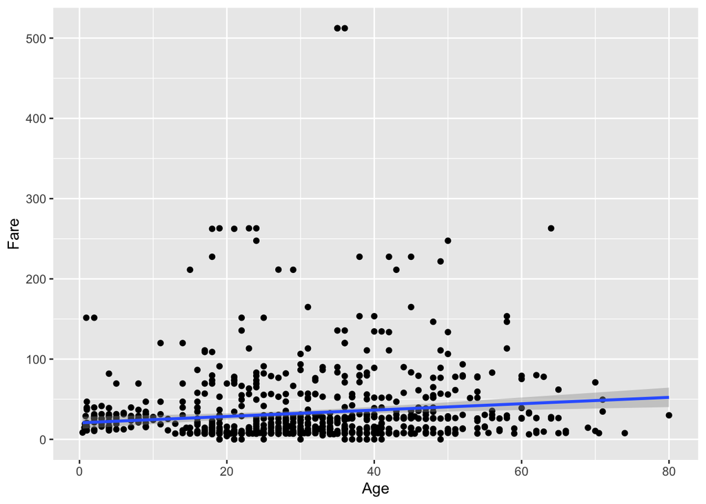

```r
ggplot(titanic,aes(x=Age,y=Fare)) +
  geom_point() +
  geom_smooth(method ="lm")
```